# Graficar en R (bias genético)

Aveces queremos graficar en páneles separados la misma info para diferentes tratamientos o especies. Por ejemplo:

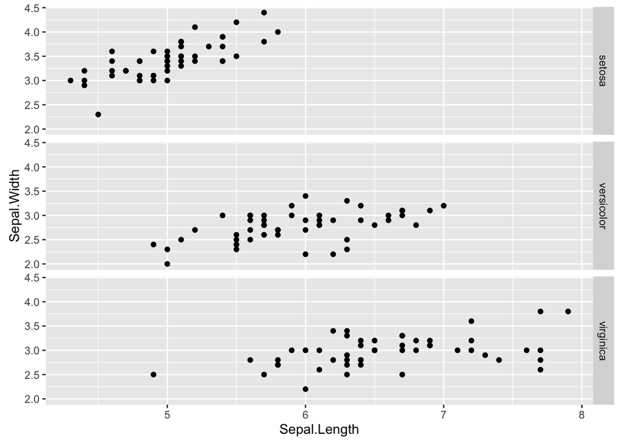

```r
ggplot(data=iris, aes(x=Sepal.Length, y= Sepal.Width)) +
  geom_point() +
  facet_grid(Species ~ .)
```

**Ejercicio** Pon color por especie a la gráfica anterior:

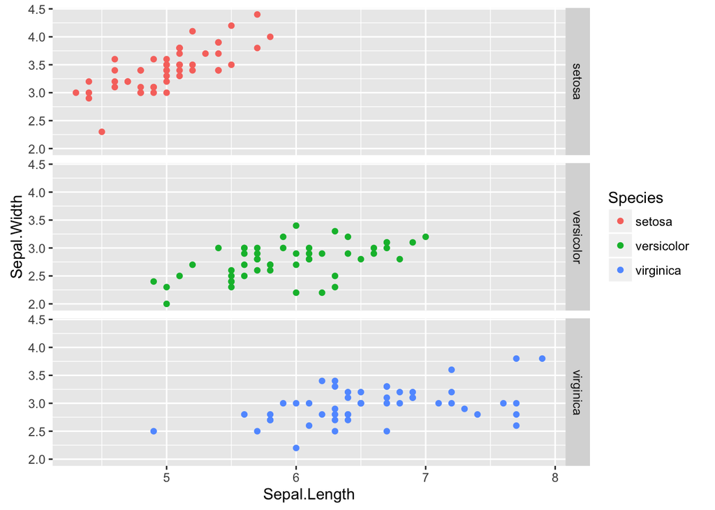

**Ejercicio** Repite la gráfica anterior pero para que se vea así:

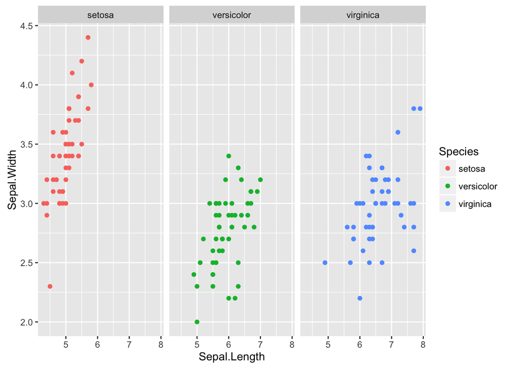

**Ejercicio** Repite la figura anterior pero cambiando los labels para que digan “Ancho de sépalo” y “Largo de sépalo”, respectivamente. Debe verse así:

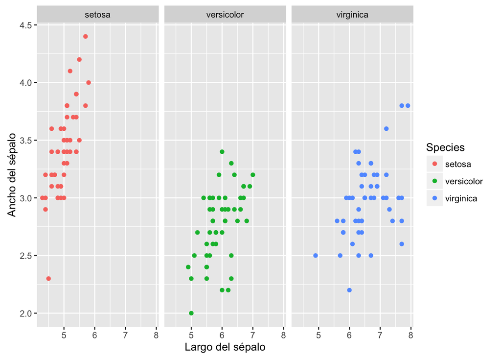

También podemos agregar el resultado de un modelo matemático, como una regresión lineal:

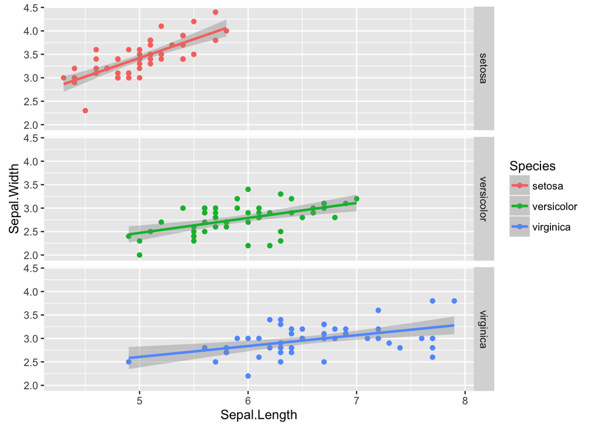

```r
ggplot(data=iris, aes(x=Sepal.Length, y= Sepal.Width, color=Species)) +
  geom_point() +
  facet_grid(Species ~ .) +
  geom_smooth(method="lm")
```

#### Barplot

En este tipo de gráficas la altura de las barras puede significar dos cosas:

- la **cuenta** (frecuencia) de casos de cada valor de x. Si quieres graficar esto utiliza `stat="bin"` en los argumentos de `geom_bar`.
- el **valor** de la columna en el set de datos. Si quieres graficar esto utiliza `stat="identity"` en los argumentos de `geom_bar`.

Ejemplo:

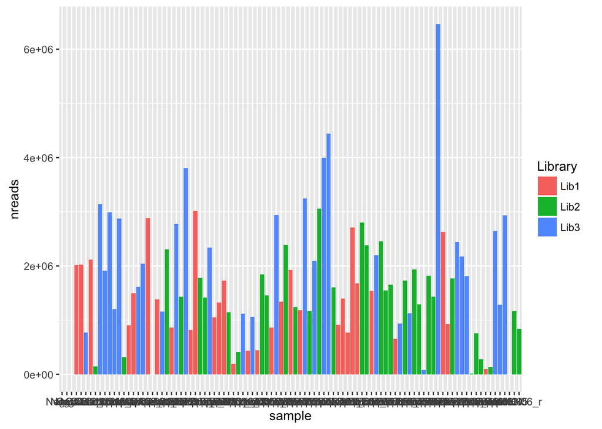

```r
# Cargar archivo
reads<-read.delim("../Practicas/Uni7/data/reads.txt")

# plot
p <- ggplot(data=reads, aes(x=sample, y=nreads, fill=Library)) +
  geom_bar(stat="identity")
p
```

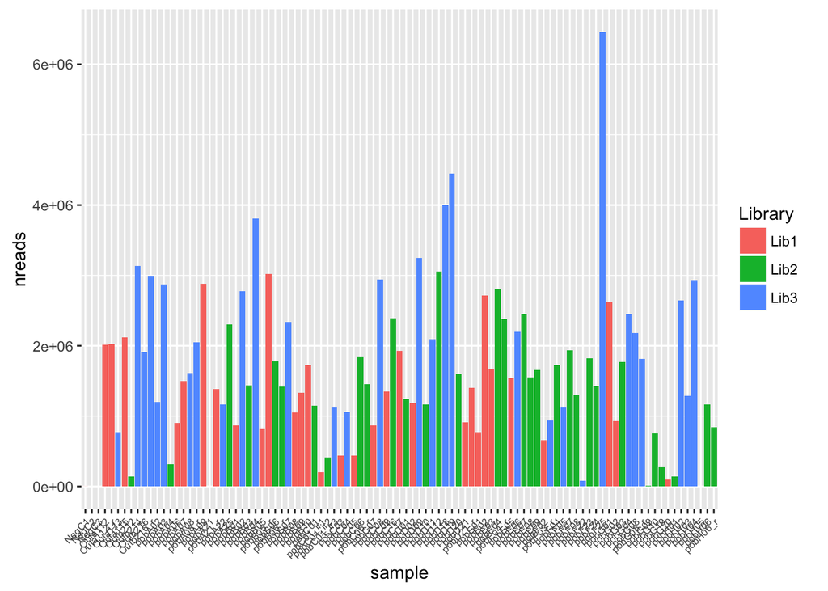

```r
# Rotar nombres muestras
p <- p +  theme(axis.text.x = element_text(angle = 45, hjust = 1, size=6))
p
```

La gráfica anterior no es igual a la que hicmos con `barplot` con los mismos datos ya que `ggplot2` grafica **en el orden de los levels**, en este caso:

```r
head(levels(reads$sample))
```

```
## [1] "NegC1"     "NegC2"     "NegC3"     "Outa112"   "Outa112_r" "Outa113"
```

Forma de solucionarlo:

```r
# Cambiar orden de levels:
reads$sample<-factor(reads$sample, levels = reads$sample[order(1:length(reads$sample))])
head(levels(reads$sample))
```

```
## [1] "pobA21_r"  "pobB10"    "pobB05"    "pobC05"    "pobD21_r"  "Outa112_r"
```

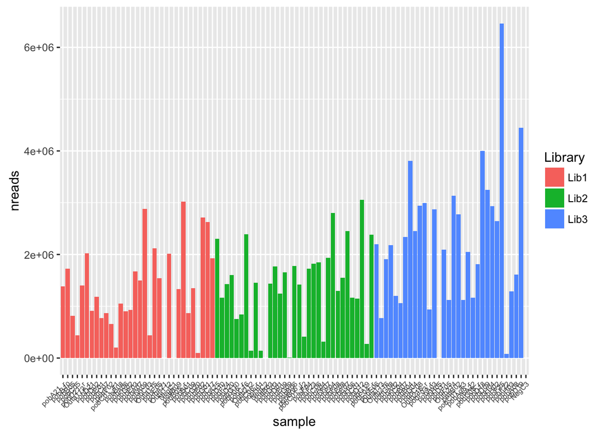

```r
# Graficar
# plot
p <- ggplot(data=reads, aes(x=sample, y=nreads, fill=Library)) + geom_bar(stat="identity")
p +  theme(axis.text.x = element_text(angle = 45, hjust = 1, size=6))
```

#### Boxplot

Siguiendo con los mismos datos anteriores:

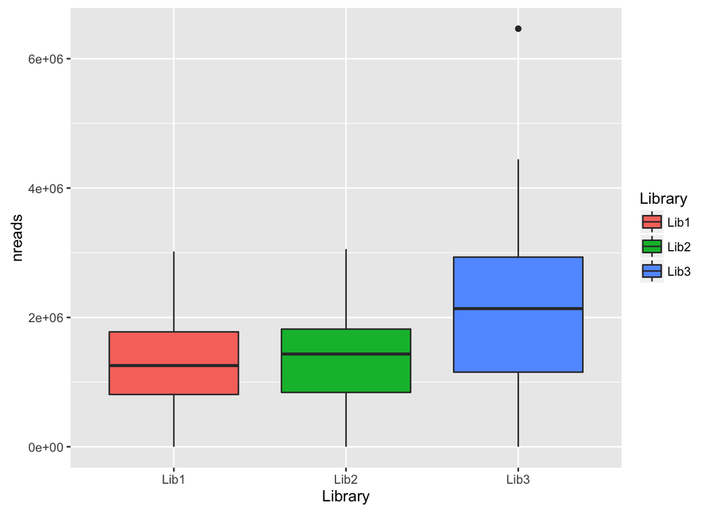

```r
# plot
p <- ggplot(data=reads, aes(x=Library, y=nreads, fill=Library)) + geom_boxplot()
p
```

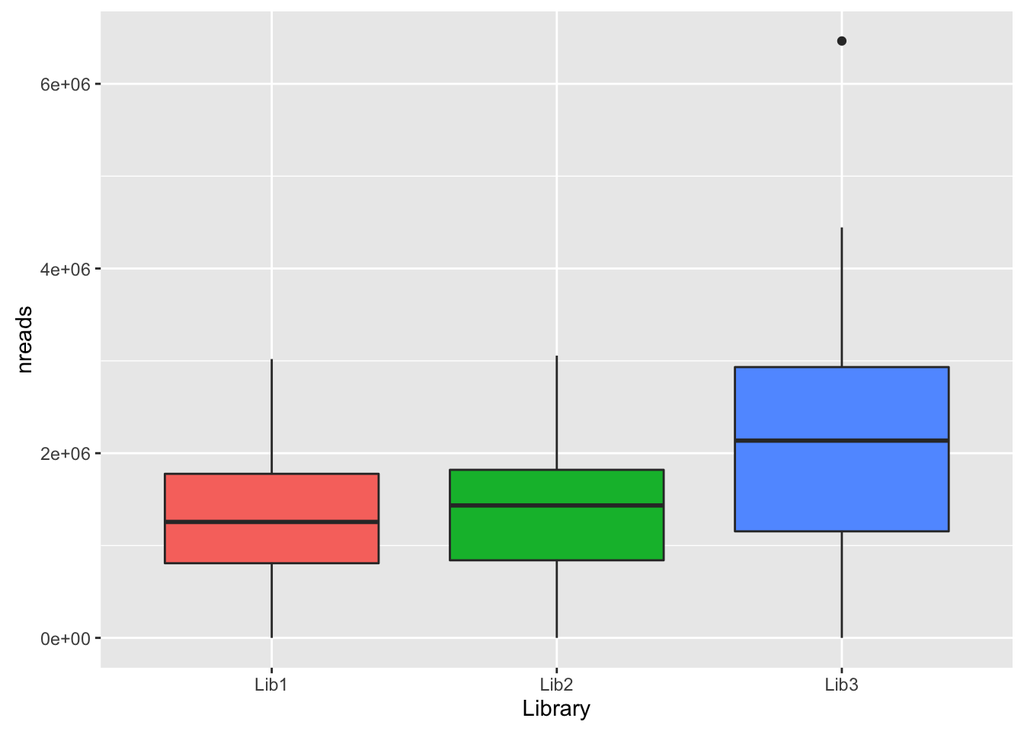

```r
# quitar leyenda
p + guides(fill=FALSE)
```

#### Árboles

Los árboles filogenéticos también pueden graficarse estilo ggplot, con el paquete de Biocounductor [ggtree](https://bioconductor.org/packages/release/bioc/html/ggtree.html), que veremos más adelante junto con otros paquetes.

### Cambiar colores en ggplot

Al igual que en base, en ggplot es posible cambiar los colores manualmente o cambiando la paleta.

Recomiendo buscar más información y ejemplos en esta excelente guía [Cookbook-R colores en ggplot2](http://www.cookbook-r.com/Graphs/Colors_%28ggplot2%29/).

Ejemplos:

**Cambiar colores manualmente**

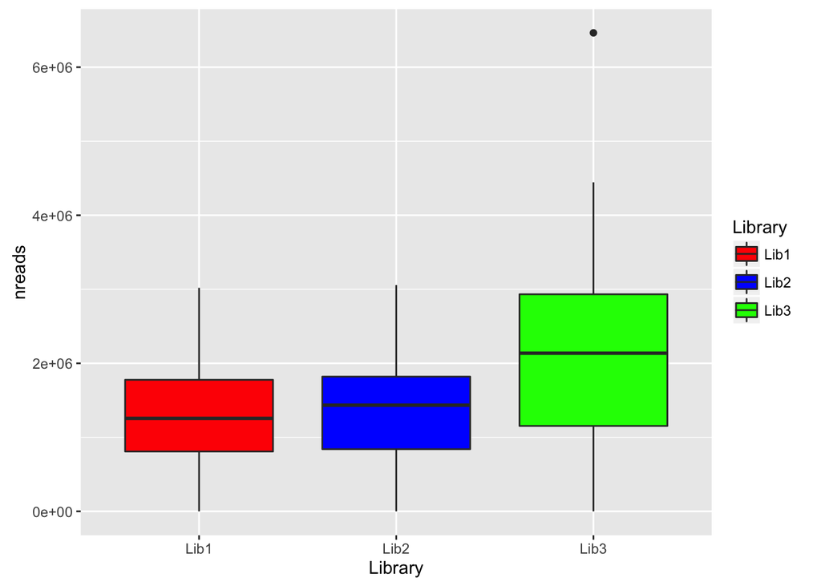

```r
# Crear paleta:
cbPalette <- c("#999999", "#E69F00", "#56B4E9", "#009E73", "#F0E442", "#0072B2", "#D55E00", "#CC79A7")

# Usar paleta en gráfica:
p <- ggplot(data=reads, aes(x=Library, y=nreads, fill=Library)) + geom_boxplot()
p + scale_fill_manual(values=c("red", "blue", "green"))
```

**Cambiar la paleta**

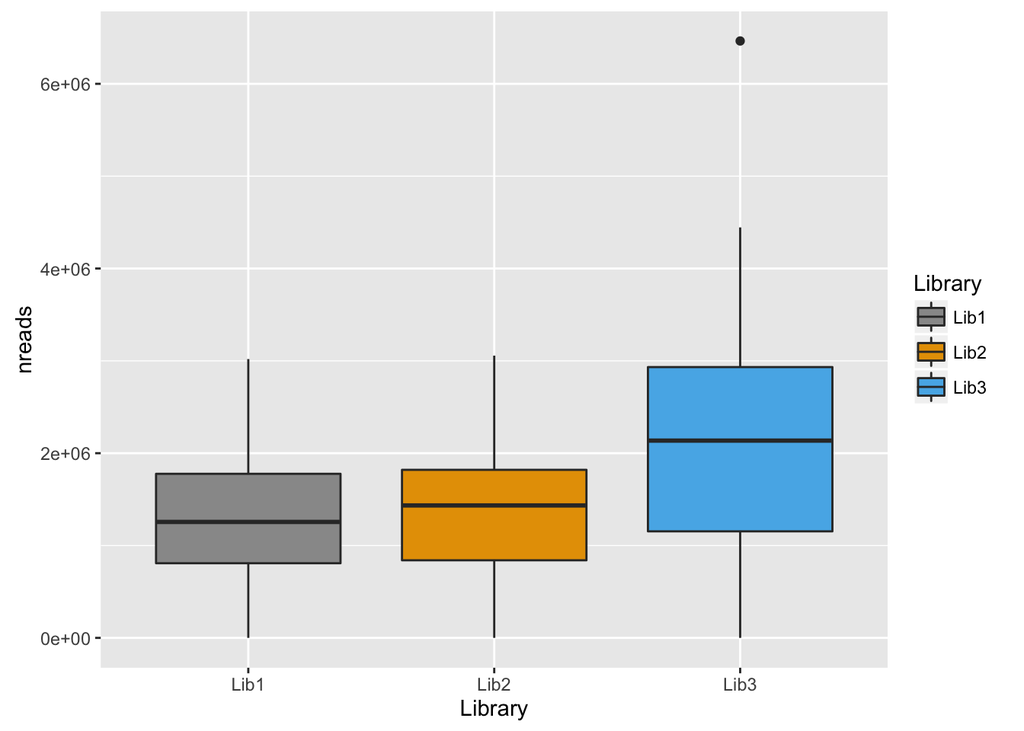

```r
# Crear paleta apta para daltónicos:
cbPalette <- c("#999999", "#E69F00", "#56B4E9", "#009E73", "#F0E442", "#0072B2", "#D55E00", "#CC79A7")

# Usar paleta en gráfica:
p <- ggplot(data=reads, aes(x=Library, y=nreads, fill=Library)) + geom_boxplot()
p + scale_fill_manual(values=cbPalette)
```

**Usar una paleta de ColorBrewer**

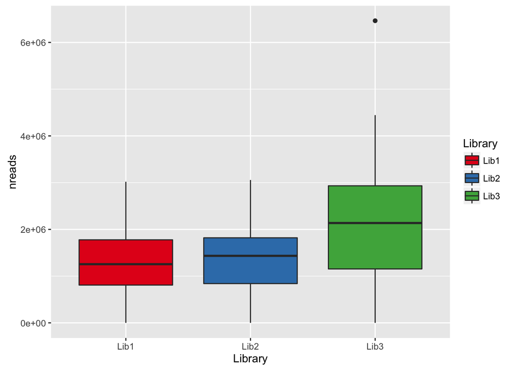

```r
p <- ggplot(data=reads, aes(x=Library, y=nreads, fill=Library)) + geom_boxplot()
p + scale_fill_brewer(palette="Set1")
```

**Utilizar gradientes de colores**

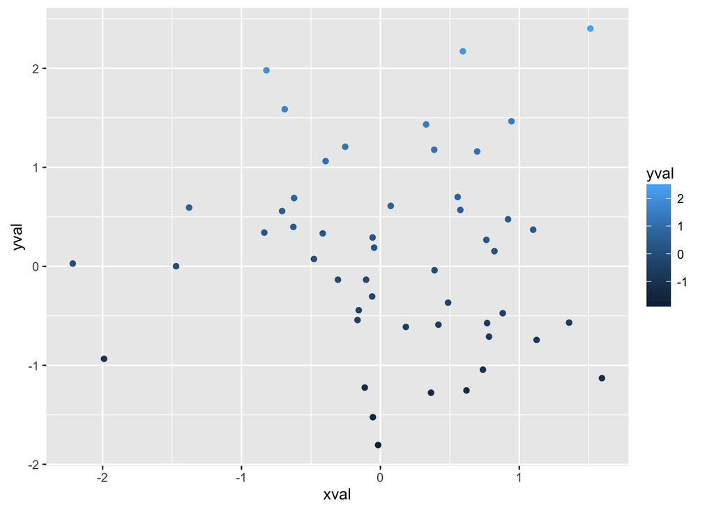

```r
# Generar datos
set.seed(1)
df <- data.frame(xval=rnorm(50), yval=rnorm(50))

# Plot
ggplot(df, aes(x=xval, y=yval, colour=yval)) + geom_point()
```

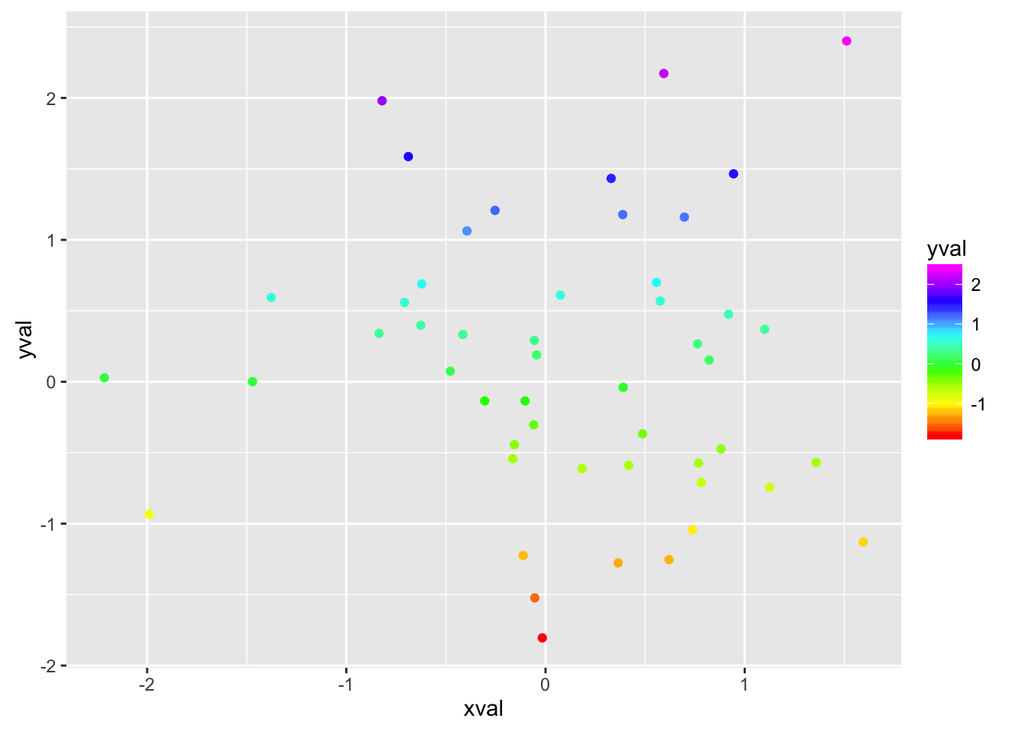

```r
# Cambiar gradiente
ggplot(df, aes(x=xval, y=yval, colour=yval)) + geom_point() +
    scale_colour_gradientn(colours=rainbow(6))
```

### Múltiples gráficas (=/= facets) en una gráfica:

Veamos este [ejemplo de R Cookbook](http://www.cookbook-r.com/Graphs/Multiple_graphs_on_one_page_%28ggplot2%29/) sobre mutlipltos:

Primero generamos y guardamos en objetos 4 gráficas:

```r
# This example uses the ChickWeight dataset, which comes with ggplot2
# First plot
p1 <- ggplot(ChickWeight, aes(x=Time, y=weight, colour=Diet, group=Chick)) +
    geom_line() +
    ggtitle("Growth curve for individual chicks")

# Second plot
p2 <- ggplot(ChickWeight, aes(x=Time, y=weight, colour=Diet)) +
    geom_point(alpha=.3) +
    geom_smooth(alpha=.2, size=1) +
    ggtitle("Fitted growth curve per diet")

# Third plot
p3 <- ggplot(subset(ChickWeight, Time==21), aes(x=weight, colour=Diet)) +
    geom_density() +
    ggtitle("Final weight, by diet")

# Fourth plot
p4 <- ggplot(subset(ChickWeight, Time==21), aes(x=weight, fill=Diet)) +
    geom_histogram(colour="black", binwidth=50) +
    facet_grid(Diet ~ .) +
    ggtitle("Final weight, by diet") +
    theme(legend.position="none")        # No legend (redundant in this graph)
```

Luego las graficamos juntas con la función `multiplot`, del paquete Rmisc:

```r
library(Rmisc)
```

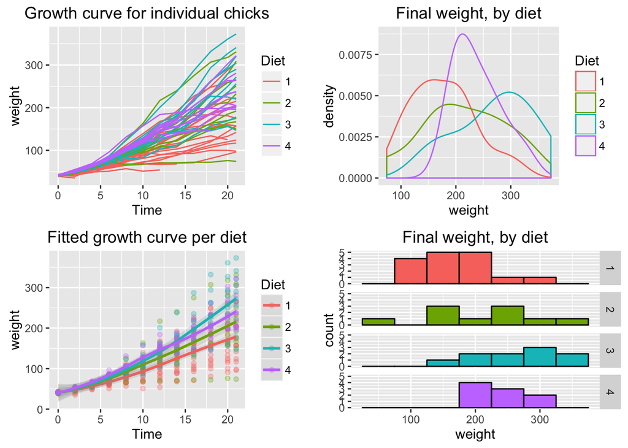

```r
multiplot(p1, p2, p3, p4, cols=2)
```